# assignment 4

Oyedayo Oyelowo

2 November 2017

```r
#clear memory
rm(list = ls())
setwd("C:/Users/oyeda/Desktop/R_COURSE/assignment4")
#load the data
data<-read.table("puudata.txt", header = T, sep = "\t")
```

### Exercise 1

- Form separate histograms for diameters (LPM) of spruces and pines (tree species = PUULAJI, pine = 1 and spruce = 2) in the first crown layer (canopy cover layer = LATVKERROS).
- Which of the two is visually closerto normal distribution?

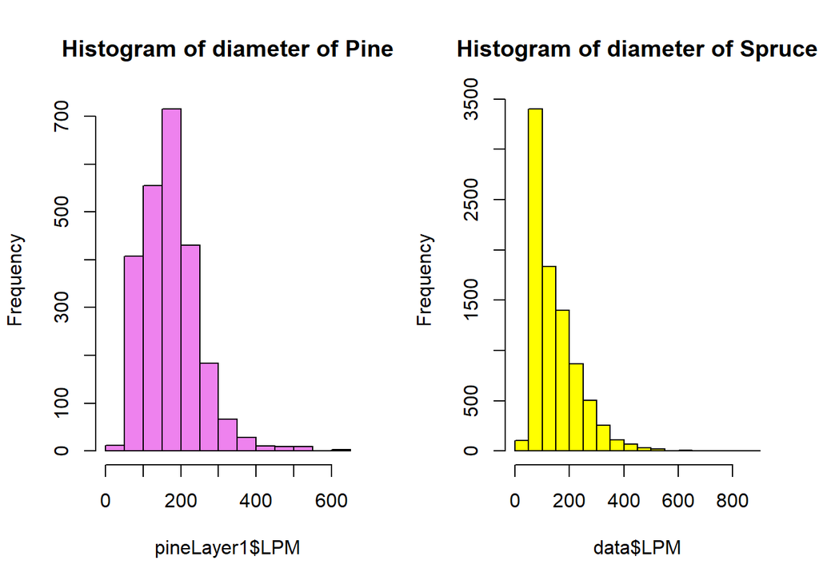

```r
par(mfcol=c(1,2))
pineLayer1<- subset(data, data$PUULAJI==1 & data$LATVKERROS==1)
pine.hist<- hist(pineLayer1$LPM, main = "Histogram of diameter of Pine",
                 col = "violet")

spruceLayer1<-subset(data, data$PUULAJI==2 & data$LATVKERROS==1)
spruce.hist<-hist(data$LPM, main = "Histogram of diameter of Spruce",
                  col="yellow")
```

**Answer: Pine apperas to be more normally distributed**

### Exercise 2

- Plot tree height (PITUUS) as function of tree diameter (LPM) (height on the y-axis and dbh on the x-axis)
- 1. for spruces in the first canopy cover layer

[figure not shown]

```r
plot(spruceLayer1$LPM, spruceLayer1$PITUUS,
     xlab = "DBH", ylab = "Height", main="Spruce in Crown Layer 2", col="red")
```

```r
#plot(x=spruceLayer1$LPM, y=spruceLayer1$PITUUS) alternatively
```

- 2. for pines in the second canopy cover layer

[figure not shown]

```r
pineLayer2<- subset(data, data$PUULAJI==1 & data$LATVKERROS==2)
plot(pineLayer2$PITUUS, pineLayer2$LPM, main = "Pines in Crown Layer 2",
     xlab = "DBH", ylab = "Height", col="brown")
```

### Exercise 3

- Form a box-and-whiskers plot for heights of conifers (species 1 and 2) in first and second crown layer.
- What can you tell from the difference between height distributions of pines and spruces?

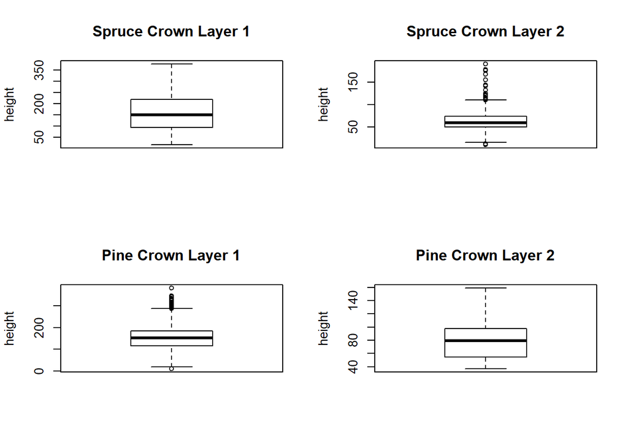

```r
par(mfrow=c(2,2), bg="white")
boxplot(spruceLayer1$PITUUS, ylab="height", main="Spruce Crown Layer 1")
spruceLayer2<-subset(data, data$PUULAJI==2 & data$LATVKERROS==2)
boxplot(spruceLayer2$PITUUS, ylab="height", main="Spruce Crown Layer 2")

boxplot(pineLayer1$PITUUS, ylab="height", main="Pine Crown Layer 1")
boxplot(pineLayer2$PITUUS, ylab="height", main="Pine Crown Layer 2")
```

### Exercise 4

- Plot the diameter, height, height of living crown (ELAVALARAJA), and width of the crown (LATVUSLEV) for silver birches (PUULAJI = 3) in the first canopy cover layer with pairs() function.
- Choose the two variables that seem to have the most linear relationship.
- Examine the distribution #of these two variables by drawing a QQ-plot.
- What can you tell from the plot?

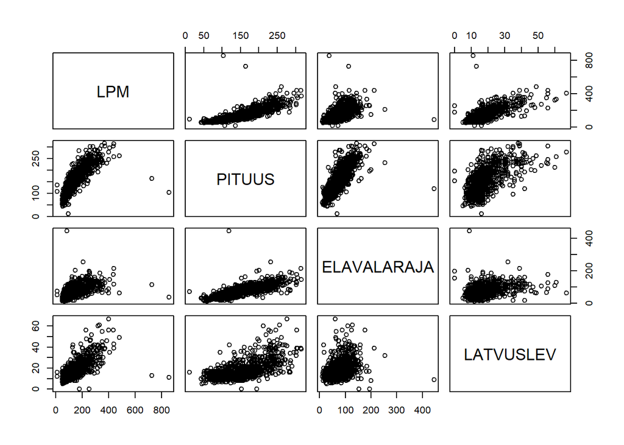

```r
s.birchLayer1<- subset(data, data$PUULAJI==3 & data$LATVKERROS==1)
#simple pairing but I used a mmore detailed pairer after this
pairs(~LPM + PITUUS + ELAVALARAJA + LATVUSLEV, data = s.birchLayer1)
```

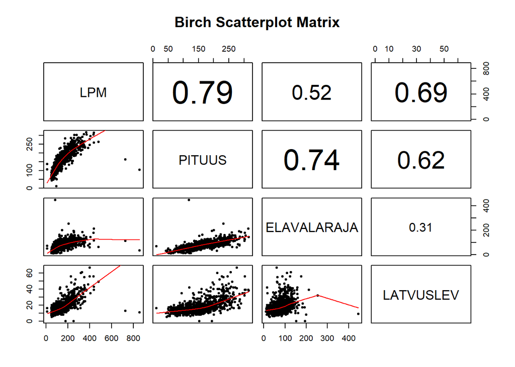

```r
## put (absolute) correlations on the upper panels,
## with size proportional to the correlations.
panel.cor <- function(x, y, digits = 2, prefix = "", cex.cor, ...)
{
  usr <- par("usr"); on.exit(par(usr))
  par(usr = c(0, 1, 0, 1))
  r <- abs(cor(x, y))
  txt <- format(c(r, 0.123456789), digits = digits)[1]
  txt <- paste0(prefix, txt)
  if(missing(cex.cor)) cex.cor <- 0.8/strwidth(txt)
  text(0.5, 0.5, txt, cex = cex.cor * r)
}

pairs(~LPM+PITUUS+ELAVALARAJA+LATVUSLEV, data=s.birchLayer1,
      lower.panel=panel.smooth, upper.panel=panel.cor,
      pch=20, main="Birch Scatterplot Matrix")
```

**diameter(LPM) and height(PITUUS), have the most linear relationship with a correation of 0.79**

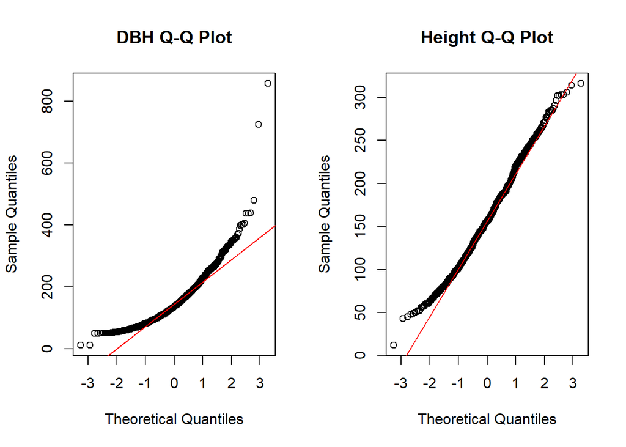

```r
#?qqplot
par(mfrow=c(1,2))
qqnorm(s.birchLayer1$LPM, main = "DBH Q-Q Plot")
qqline(s.birchLayer1$LPM, col="red")

qqnorm(s.birchLayer1$PITUUS, main = "Height Q-Q Plot")
qqline(s.birchLayer1$PITUUS, col="red")
```

**diameter(LPM) is not normally distributed but skewed to the right, height appears to be normally distributed**

- **Although, The Shapiro-Wilk test for normality is used to examine a continuous variable, I decided to apply it here too.**

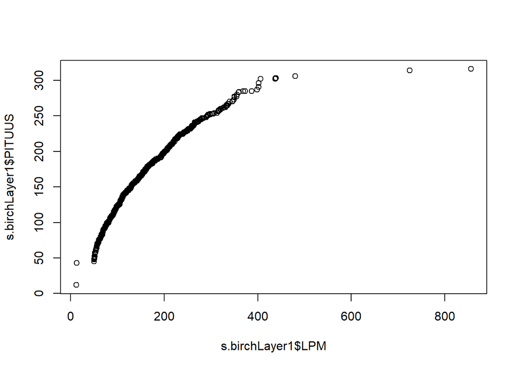

```r
a<-qqplot(s.birchLayer1$LPM, s.birchLayer1$PITUUS, plot.it = TRUE,
       xlab = deparse(substitute(s.birchLayer1$LPM)),
       ylab = deparse(substitute(s.birchLayer1$PITUUS)))
```

```r
#?shapiro.test
shapiro.test(s.birchLayer1$LPM)
```

```
##
##  Shapiro-Wilk normality test
##
## data:  s.birchLayer1$LPM
## W = 0.87534, p-value < 2.2e-16
```

```r
shapiro.test(s.birchLayer1$PITUUS)
```

```
##
##  Shapiro-Wilk normality test
##
## data:  s.birchLayer1$PITUUS
## W = 0.99075, p-value = 1.52e-05
```

**based on the fact that the p values of the height and DBH(LPM) are less than 0.05, we can reject the null hypothesis that the data the data are normally distributed**